# caret demostration with kaggle bikeshare data (I)

### Purpose

- This is a demostration to solve regression problem with some (popular?) models in *caret*.
- The data is from the kaggle: bicycle sharing competition. The features of data are quite clean, straightforward, and complete. No need to do much data cleanning, so that we can focus on comparing the models.
- Included models: tree-based models (*ctree*, *rpart*), boosting models (*gbm*, *gamboost*), bagged models (*treebag*, *bagEarth*), random forest (*rf*, *cforest*, *qrf*), linear regression models (*enet*, *pcr*, *glmnet*), Radial-kernal regression (*rvmRadial*), and neural network (*nnet*, *pcaNNet*, *neuralnet*).
- The list is by no means complete. For each model, I only try a grid of simple/convenient parameters. The purpose is to taste a’s many models as I could, and I am not intended to do a serious benchmark comparisons between models.

### Data

- data loading
- split the datetime to hour, month, year, and wday using strptime
- calculate log(count+1) to replace count, which will be used for prediction. Advantage: 1. the evalutation RMSLE metrics will be transofrmed to RMSE, one of the default metrics in *caret::train*. 2. The prediction of regression won’t be negative.
- removing the unnecesary features 1. casual, register: Useless – not appear in the test set. 2. datetime, count: Redaudant – replaced by new features

```r
train <- read.csv("../DATA/train.csv", colClasses=test_classes)
test <- read.csv("../DATA/test.csv", colClasses=test_classes[1:9])
train$count <- as.integer(train$count)

train_factor <- set_up_features(train)
test_factor <- set_up_features(test)

train_factor$lgcount <- log(train_factor$count+1)
train_factor<- train_factor[,-12]
train_factor<- train_factor[,-11]
train_factor<- train_factor[,-10]
train_factor<- train_factor[,-1]
test_factor<- test_factor[,-1]
```

### Sample split and CV optimization – use *caret*

Split the sample into 20% testing subsample and 80% trainning subsample.

```r
set.seed(212312)
trainIndex <- createDataPartition(train_factor$lgcount, p = 0.8, list=FALSE, times=1)
subTrain <- train_factor[trainIndex,]
subTest <- train_factor[-trainIndex,]
```

### A simple tree model

```r
library(party)
#create our formula
formula <- lgcount ~ season + holiday + workingday + weather + temp + atemp + humidity + windspeed + hour + wday + month + year
#build our model
fit.ctree.party <- ctree(formula, data=subTrain,controls=ctree_control(mincriterion=0.95,savesplitstats=FALSE))
```

```
##             Test.rmsle Test.rmse Train.RMSLE Train.RMSE
## ctree.party  0.4177777  55.68874   0.3658089   46.97015
```

```
## [1] object.size:  45.7 Mb
```

- The RMSLE of left-out testing subsample is 0.418. Not bad, actually.
- The tree is quite large (~46MBs), and I don’t know how to examine the result easily. Let’s try *caret* instead.

### Modeling with *caret*

#### Try to reproduce the *party::ctree* result with trainning subsample

```r
# all features
formula <- lgcount ~ season + holiday + workingday + weather + temp + atemp + humidity + windspeed + hour + wday + month + year
fit.ctree <- train(formula, data=subTrain,method='ctree',tuneGrid=expand.grid(mincriterion=0.95))
ctreeVarImp = varImp(fit.ctree)
```

```
##                   Test.rmsle Test.rmse Train.RMSLE Train.RMSE
## ctree.caret.plain  0.5436062  84.36475   0.5015594   77.92729
```

```
## [1] object.size:  51.4 Mb
```

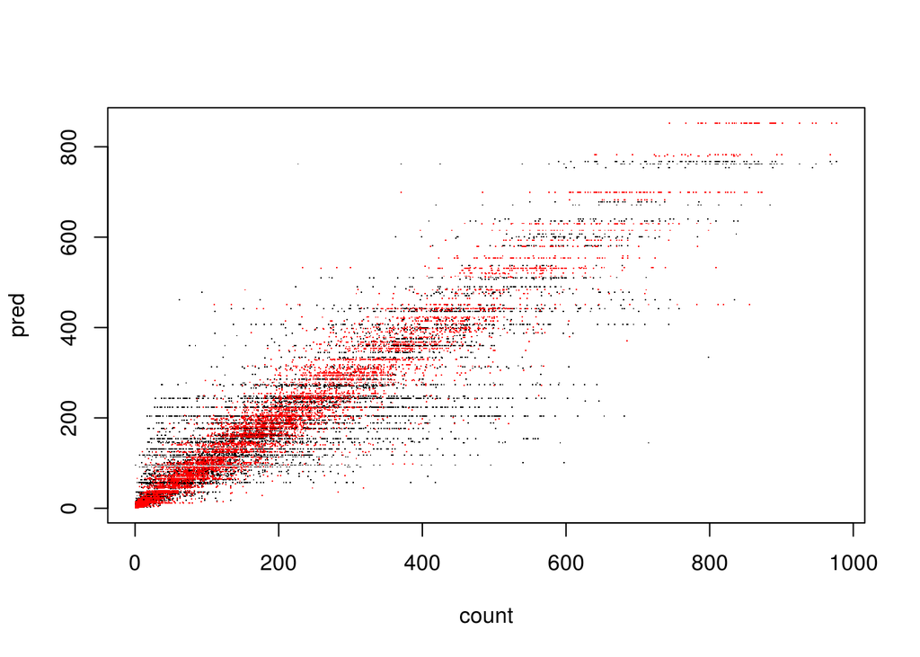